# Linear and Non-Linear Principal Component Analysis Techniques

Roger Bukuru

2024-06-02

# Introduction

- Projection of high-dimensional data into a lower-dimensional subspace by creating a reduced set of linear transformations of the input variables, also called “feature extraction”.
- An eigenvalue-eigenvector problems but can also be viewed as special case of multivariate reduced rank regression.
- Aimed at finnding linear orthogonal combinations (projections) of the input variables that are ordered by decreasing variance.
- Main aim is that of dimension reduction.
- Can also be used to discover important features of the data using graphical displays of the principal component scores.

# Classic PCA (Linear Technique)

- PCA from eigen decomposition

```r
rm(list = ls())
library(tidyverse)
library(dplyr)
library(rrr)
library(ggplot2)
library(scatterplot3d)
library(plotly)


data("iris")

iris_data = iris %>%
       as.tibble()
head(iris)
```

```
##   Sepal.Length Sepal.Width Petal.Length Petal.Width Species
## 1          5.1         3.5          1.4         0.2  setosa
## 2          4.9         3.0          1.4         0.2  setosa
## 3          4.7         3.2          1.3         0.2  setosa
## 4          4.6         3.1          1.5         0.2  setosa
## 5          5.0         3.6          1.4         0.2  setosa
## 6          5.4         3.9          1.7         0.4  setosa
```

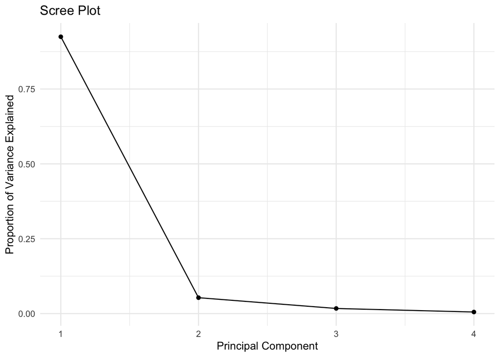

```r
x  = iris_data[,1:4]
# Center data
x_c = apply(x, 2, function(x)(x-mean(x)))
x_cov = cov(x)

eigen_decomp = eigen(x_cov)

eigenvectors = eigen_decomp$vectors # Principal Components
eigenvalues  = eigen_decomp$values
pca_scores   = t(eigenvectors%*%t(x_c)) %>% as.tibble()

pca_components_variance = (eigenvalues)/sum(eigenvalues)
pca_components_variance_df = data.frame(`PC` = 1:length(pca_components_variance), `Var Explained` = pca_components_variance) %>% as.tibble()

# Plot Scree Plot
ggplot(pca_components_variance_df, aes(x = PC, y = Var.Explained)) +
  geom_point() + # Add points
  geom_line() + # Connect points with lines
  xlab("Principal Component") +
  ylab("Proportion of Variance Explained") +
  ggtitle("Scree Plot") +
  theme_minimal() # Using a minimal theme for aesthetics
```

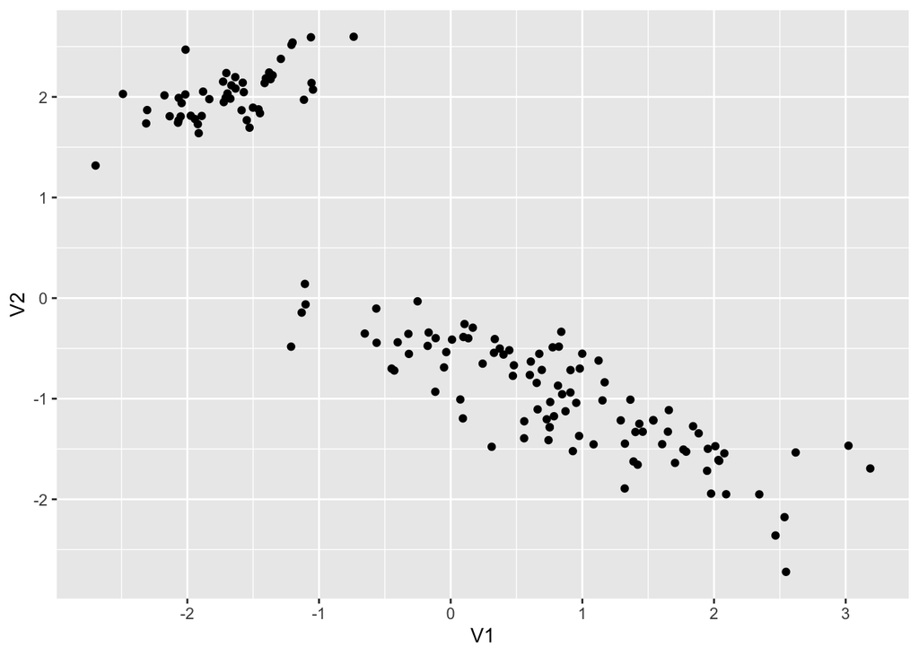

```r
# Plot PCA Scores
ggplot(data = pca_scores, mapping = aes(x = V1, y = V2))+
      geom_point()
```

- PCA using in built package

```r
rm(list = ls())
library(tidyverse)
library(dplyr)
library(rrr)
library(ggplot2)
library(scatterplot3d)
library(plotly)

data("iris")

iris_data = iris %>%
       as.tibble()
head(iris)
```

```
##   Sepal.Length Sepal.Width Petal.Length Petal.Width Species
## 1          5.1         3.5          1.4         0.2  setosa
## 2          4.9         3.0          1.4         0.2  setosa
## 3          4.7         3.2          1.3         0.2  setosa
## 4          4.6         3.1          1.5         0.2  setosa
## 5          5.0         3.6          1.4         0.2  setosa
## 6          5.4         3.9          1.7         0.4  setosa
```

```r
X  = iris_data[,1:4]

classic_pca = prcomp(X, retx = TRUE, center = TRUE, scale. =  FALSE)
pca_components = classic_pca$rotation
pca_scores = classic_pca$x%>% # Linear combination of centered data and eigenvectors
             as.tibble()
pca_classic_variance_explained = (classic_pca$sdev^2)/sum(classic_pca$sdev^2)
pca_classic_variance_explained_df = data.frame(`PC` = 1:length(pca_classic_variance_explained), `Var Explained` = pca_classic_variance_explained) %>% as.tibble()

summary(classic_pca)
```

```
## Importance of components:
##                           PC1     PC2    PC3     PC4
## Standard deviation     2.0563 0.49262 0.2797 0.15439
## Proportion of Variance 0.9246 0.05307 0.0171 0.00521
## Cumulative Proportion  0.9246 0.97769 0.9948 1.00000
```

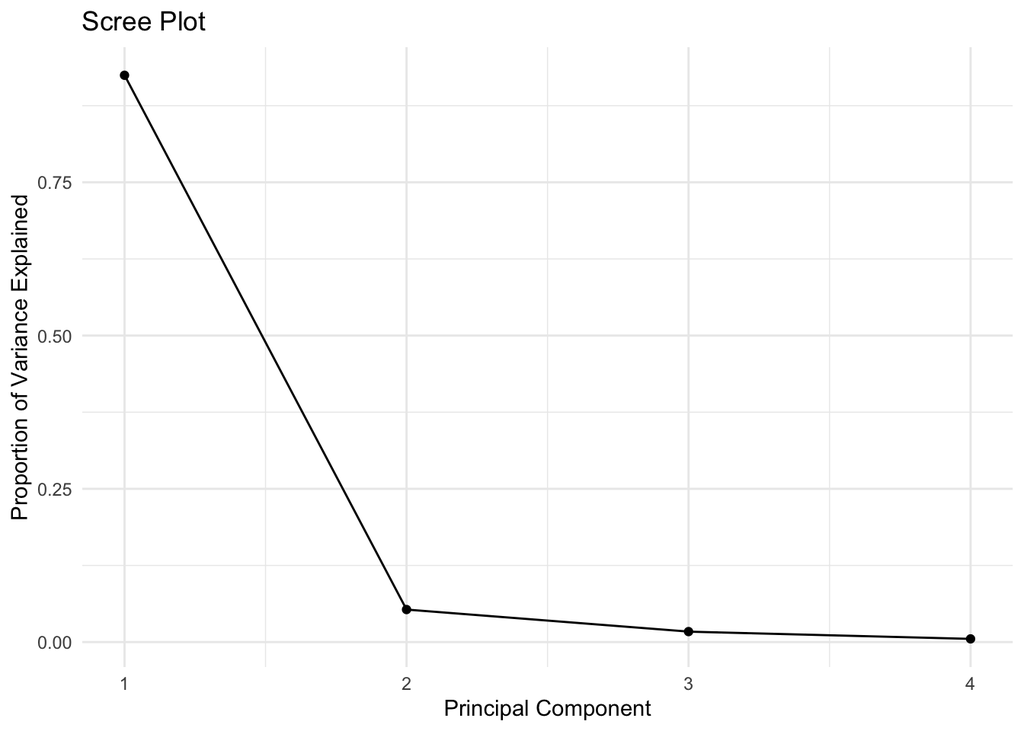

```r
# Plot Scree Plot
ggplot(pca_classic_variance_explained_df, aes(x = PC, y = Var.Explained)) +
  geom_point() + # Add points
  geom_line() + # Connect points with lines
  xlab("Principal Component") +
  ylab("Proportion of Variance Explained") +
  ggtitle("Scree Plot") +
  theme_minimal() # Using a minimal theme for aesthetics
```

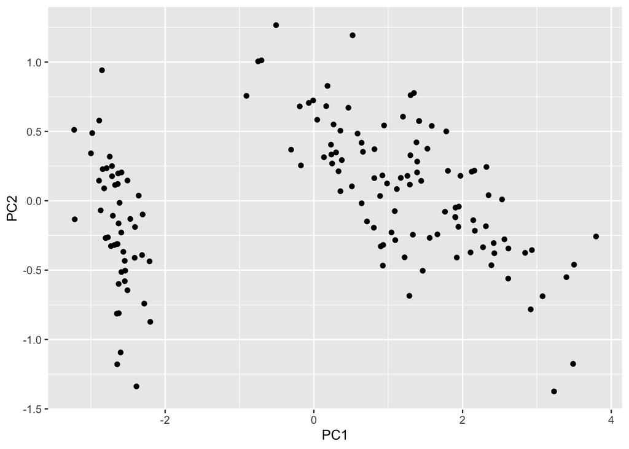

```r
# Plot PCA Scores
ggplot(data = pca_scores, mapping = aes(x = PC1, y = PC2))+
      geom_point()
```

# Non-Linear PCA Techniques

- We have little visual guidance to help us identify any meaningful low-dimensional structure hidden in high-dimensional data.
- The linear projection methods are useful in discovering low-dimensional structure when the data actually lie in a linear (or approximately linear) lower-dimensional subspace (called a manifold $M$) of input space $R^d$
- But linear methods will not be able to capture the curvature of the data. What can we do if we know or suspect that the data actually lie on a low-dimensional nonlinear manifold, whose structure and dimensionality are both assumed unknown ?
- When a linear representation of the data is unsatisfactory, we turn to specialized methods designed to recover nonlinear structure.
  - identify the nonlinear manifold $M$

## Polynomial PCA

- Idea of generalizing PCA to a nonlinear case.
- We transform the set of input variables using a quadratic, cubic, or higher degree polynomial, and then apply linear PCA.
- The resulting polynomial PCA comes down to eigen analysis, by this time attention is focused on the value of the smallest few eigenvalues for nonlinear dimensionality reduction
- If for example we have bivariate data and the data follow an exact quadratic curve, the smallest eigenvalue of the covariance matrix of the extended vector will be zero and the score of the last principal component will be constant with a value of zero

### Polynomial PCA Steps:

- Extend the input variables to an $s$ degree polynomial i.e increase the dimension of the input space
- From the extended input space perform linear PCA
  - The idea is that in a some input space, the data will be linear i.e the points, such that we can use a linear transformation within this space to reduce the dimension.
- Example with no noise

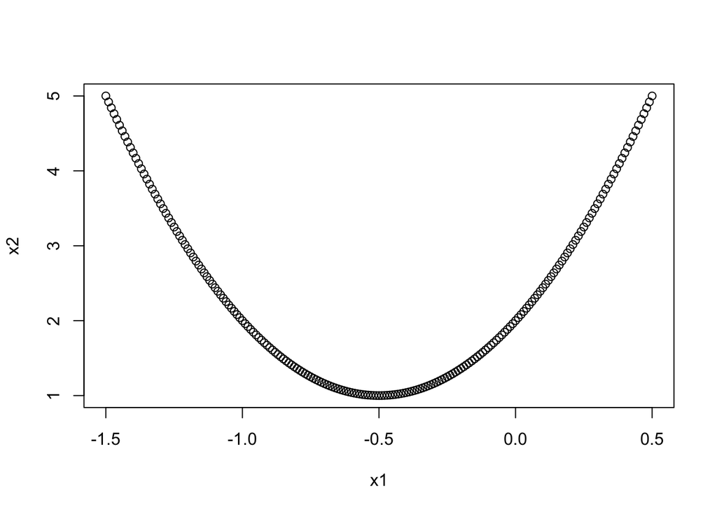

```r
rm(list = ls())
library(tidyverse)
library(dplyr)
library(rrr)
library(ggplot2)
library(scatterplot3d)
library(plotly)

n = 201
x1 = seq(from = -1.5, to = 0.5, by = 0.01)
x2 = 4*x1^2 + 4*x1 + 2
plot(x1,x2) # initial plot of the data (this is the initial input space, where we suspect that the relationship in the data is non-linear)
```

```r
# We can start by performing standard linear PCA
original_data = data.frame(x1,x2)
linear_pca = prcomp(original_data, center = TRUE)
summary(linear_pca)
```

```
## Importance of components:
##                           PC1    PC2
## Standard deviation     1.2075 0.5817
## Proportion of Variance 0.8116 0.1884
## Cumulative Proportion  0.8116 1.0000
```

```r
# We extend the data
data_transformed = data.frame(x1,x2, x1^2, x2^2, x1*x2) # quadratic approximation using polynomial PCA
svd_output = svd(cov(data_transformed))

principal_components = round(svd_output$v,3)
eigenvalues = round(svd_output$d,3)
# Observe that the
principal_components
```

```
##        [,1]   [,2]   [,3]   [,4]   [,5]
## [1,] -0.003 -0.252  0.662 -0.115 -0.696
## [2,]  0.173 -0.013  0.336  0.909  0.174
## [3,]  0.046  0.249 -0.578  0.342 -0.696
## [4,]  0.979 -0.102 -0.063 -0.165  0.000
## [5,] -0.097 -0.929 -0.333  0.128  0.000
```

```r
eigenvalues
```

```
## [1] 46.955  4.937  0.052  0.050  0.000
```

```r
pca.transforemd = prcomp(data_transformed) # PCA on the var-cov matrix
summary(pca.transforemd)
```

```
## Importance of components:
##                           PC1     PC2    PC3     PC4       PC5
## Standard deviation     6.8524 2.22184 0.2276 0.22324 1.819e-16
## Proportion of Variance 0.9031 0.09495 0.0010 0.00096 0.000e+00
## Cumulative Proportion  0.9031 0.99805 0.9990 1.00000 1.000e+00
```

```r
variance.transformed = round(pca.transforemd$sdev^2,4)

## Loadings (PCA components)
loadings.transformed = round(pca.transforemd$rotation,4)

## PCA scores
scores.transformed = pca.transforemd$x
round(scores.transformed[5], 3)
```

```
## [1] -15.718
```

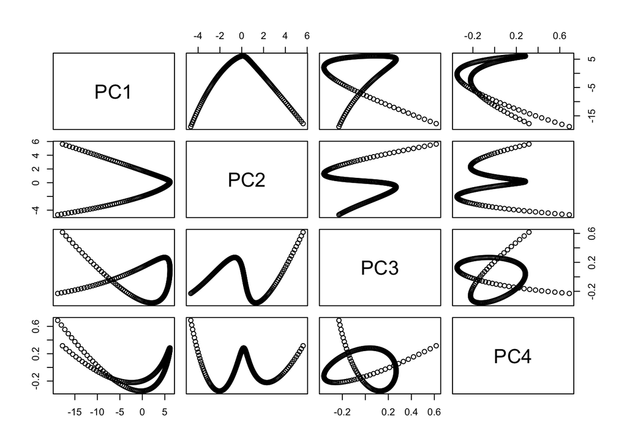

```r
pairs(scores.transformed[,1:4])
```

**From the above**

**Interpretation of pairwise scatterplot matrix**

- C1 vs. C2: Shows a non-linear, almost parabolic relationship. This indicates that the first and second principal components are capturing some quadratic structure in the data.
- C1 vs. C3: Exhibits a similar non-linear relationship, suggesting that C3 also captures additional quadratic interactions not fully explained by C1.
- C1 vs. C4: This scatterplot shows a more complex, possibly intertwined structure, indicating even higher-order interactions captured by C4.
- C2 vs. C3: Displays another non-linear relationship, highlighting that C2 and C3 capture distinct but related aspects of the quadratic structure in the data.
- C2 vs. C4: The pattern here suggests a complex interaction, reinforcing the idea that C4 is capturing variance not fully explained by the first three components.

C3 vs. C4: Shows an intricate, possibly circular pattern, indicating that C3 and C4 are capturing unique quadratic effects in the data.

# Appendix

## LLM Finetuning

- Check if inputs are correlated before performing PCA
- Check if PCA is appropriate for the data, by analysis the first few principal components in terms of linearity
- Standardize data by centering and scaling (unit variance)